# Working with Zonation results

Joona Lehtomäki

2017-07-09

## 1. Introduction to working with Zonation results

First, let’s set up the scene. For the examples below to work, make sure you have installed [`zdat`](https://github.com/cbig/zdat) package. If not, do the following:

```r
install.packages('zdat', repos='https://jlehtoma.github.io/drat/',
                 type='source')
```

Now we start working with `zonator`.

```r
library(zonator)

# Start by creating a project using the tutorial data
setup.dir <- system.file("extdata/basic", package = "zdat")
tutorial.project <- load_zproject(setup.dir)

# Get a specific variant, 01_core_area_zonation
variant.caz <- get_variant(tutorial.project, "01")

# Let's also rename the features and groups while we're at it
featurenames(variant.caz) <- c("Koala", "Masked.owl", "Powerful.owl",
                             "Tiger.quoll", "Sooty.owl", "Squirrel.glider",
                             "Yellow-bellied.glider")

groupnames(variant.caz) <- c("1" = "mammals", "2" = "owls")
```

Each variant can either already have results (i.e. Zonation run has completed) or then not. Which results exactly are available can be determined by using method `has_results()`.

```r
has_results(variant.caz)
```

```
## $curves
## [1] TRUE
##
## $grp.curves
## [1] TRUE
##
## $rank
## [1] TRUE
##
## $wrscr
## [1] FALSE
##
## $prop
## [1] FALSE
##
## $ppa.lsm
## [1] FALSE
##
## $features.info
## [1] TRUE
```

Value `TRUE` indicates that Zonation has already been run and results are available and `FALSE` indicates that results are not available.

Results of a given variant - if present - can be extracted using `results()`. The resulting object will be an instance of `Zresults` class.

```r
results.caz <- results(variant.caz)
```

Object `results.caz` can in turn be queried with various dedicated methods described in more detail below.

## 2. Performance curves

### 2.1 Working with performance data

Raw curves data (with or without groups) can be extracted from the variant or results using `curves()`. Optional argument `groups` defines whether feature or group specific curves are returned. If you don’t need every feature or aggregate statistic, you can also get the data for particular features.

```r
# Get feature-specific curves
feature.curves.caz <- curves(results.caz)
head(feature.curves.caz)
```

```
##   pr_lost   cost  min_pr  ave_pr    w_pr  ext1    ext2 Koala Masked.owl Powerful.owl Tiger.quoll Sooty.owl
## 1 0.00002 110280 1.00000 1.00000 1.00000 0e+00 0.00000 1.000      1.000        1.000           1     1.000
## 2 0.00102 110170 0.99959 0.99976 0.99976 3e-05 0.00006 1.000      1.000        1.000           1     1.000
## 3 0.00201 110060 0.99915 0.99949 0.99949 4e-05 0.00013 0.999      1.000        0.999           1     0.999
## 4 0.00301 109950 0.99866 0.99918 0.99918 5e-05 0.00021 0.999      1.000        0.999           1     0.999
## 5 0.00401 109840 0.99813 0.99883 0.99883 6e-05 0.00029 0.998      0.999        0.998           1     0.999
## 6 0.00501 109730 0.99757 0.99847 0.99847 6e-05 0.00038 0.998      0.999        0.998           1     0.998
##   Squirrel.glider Yellow-bellied.glider
## 1           1.000                 1.000
## 2           1.000                 1.000
## 3           0.999                 1.000
## 4           0.999                 0.999
## 5           0.998                 0.999
## 6           0.998                 0.999
```

```r
# Note! Using curves() variant.caz will work as well
feature.curves.caz <- curves(variant.caz)
head(feature.curves.caz)
```

```
##   pr_lost   cost  min_pr  ave_pr    w_pr  ext1    ext2 Koala Masked.owl Powerful.owl Tiger.quoll Sooty.owl
## 1 0.00002 110280 1.00000 1.00000 1.00000 0e+00 0.00000 1.000      1.000        1.000           1     1.000
## 2 0.00102 110170 0.99959 0.99976 0.99976 3e-05 0.00006 1.000      1.000        1.000           1     1.000
## 3 0.00201 110060 0.99915 0.99949 0.99949 4e-05 0.00013 0.999      1.000        0.999           1     0.999
## 4 0.00301 109950 0.99866 0.99918 0.99918 5e-05 0.00021 0.999      1.000        0.999           1     0.999
## 5 0.00401 109840 0.99813 0.99883 0.99883 6e-05 0.00029 0.998      0.999        0.998           1     0.999
## 6 0.00501 109730 0.99757 0.99847 0.99847 6e-05 0.00038 0.998      0.999        0.998           1     0.998
##   Squirrel.glider Yellow-bellied.glider
## 1           1.000                 1.000
## 2           1.000                 1.000
## 3           0.999                 1.000
## 4           0.999                 0.999
## 5           0.998                 0.999
## 6           0.998                 0.999
```

```r
# Get just 2 species
duo.curves.caz <- curves(results.caz, cols = c("Koala", "Tiger.quoll"))
head(duo.curves.caz)
```

```
##   pr_lost Koala Tiger.quoll
## 1 0.00002 1.000           1
## 2 0.00102 1.000           1
## 3 0.00201 0.999           1
## 4 0.00301 0.999           1
## 5 0.00401 0.998           1
## 6 0.00501 0.998           1
```

Columns are exactly the same as in Zonation curves output file. Note also that the actual feature columns are named according to feature names in the `Zvariant` object these results were derived from. Thus whatever names you assigned to features prior to extracting the results will be also seen here.

Let’s see what the group curves data looks like as a whole or for individual groups:

```r
# Get group-specific curves
feature.grp.curves.caz <- curves(results.caz, groups = TRUE)
head(feature.grp.curves.caz)
```

```
##   pr_lost   cost min.mammals mean.mammals max.mammals w.mean.mammals ext2.mammals min.owls mean.owls max.owls
## 1 0.00002 110280       1.000      1.00000           1        1.00000           NA    1.000 1.0000000    1.000
## 2 0.00102 110170       1.000      1.00000           1        1.00000           NA    1.000 1.0000000    1.000
## 3 0.00201 110060       0.999      0.99950           1        0.99950           NA    0.999 0.9993333    1.000
## 4 0.00301 109950       0.999      0.99925           1        0.99925           NA    0.999 0.9993333    1.000
## 5 0.00401 109840       0.998      0.99875           1        0.99875           NA    0.998 0.9986667    0.999
## 6 0.00501 109730       0.998      0.99875           1        0.99875           NA    0.998 0.9983333    0.999
##   w.mean.owls ext2.owls
## 1   1.0000000        NA
## 2   1.0000000        NA
## 3   0.9993333        NA
## 4   0.9993333        NA
## 5   0.9986667        NA
## 6   0.9983333        NA
```

```r
# Get all the aggregate stats for owls
owls.grp.curves.caz <- curves(results.caz, groups = TRUE,
                              cols = c("min.owls", "mean.owls", "max.owls",
                                     "w.mean.owls", "ext2.owls"))
head(owls.grp.curves.caz)
```

```
##   pr_lost min.owls mean.owls max.owls w.mean.owls ext2.owls
## 1 0.00002    1.000 1.0000000    1.000   1.0000000        NA
## 2 0.00102    1.000 1.0000000    1.000   1.0000000        NA
## 3 0.00201    0.999 0.9993333    1.000   0.9993333        NA
## 4 0.00301    0.999 0.9993333    1.000   0.9993333        NA
## 5 0.00401    0.998 0.9986667    0.999   0.9986667        NA
## 6 0.00501    0.998 0.9983333    0.999   0.9983333        NA
```

Often a particular range of cell removal process is more interesting than the whole range. `curves()` has arguments `lost.lower` and `lost.upper` to define a specific range:

```r
# Get performance values for 2 species for a range between 60% and 75% of
# landscape lost
duo.curves.caz.range <- curves(results.caz, cols = c("Koala", "Tiger.quoll"),
                               lost.lower = 0.6, lost.upper = 0.75)
head(duo.curves.caz.range)
```

```
##   pr_lost Koala Tiger.quoll
## 1 0.60047 0.489       0.509
## 2 0.60147 0.488       0.508
## 3 0.60247 0.486       0.506
## 4 0.60347 0.485       0.505
## 5 0.60446 0.484       0.504
## 6 0.60546 0.483       0.503
```

```r
tail(duo.curves.caz.range)
```

```
##     pr_lost Koala Tiger.quoll
## 145 0.74410 0.326       0.338
## 146 0.74510 0.325       0.337
## 147 0.74610 0.324       0.335
## 148 0.74710 0.323       0.334
## 149 0.74809 0.322       0.333
## 150 0.74909 0.320       0.332
```

Sometimes you might also be interested in performance values of features at specific levels of landscape protection. For example, how much of the original occurrence levels are remaining when 25%, 50%, and 75% of landscape is lost. Method `performance()` can give you exactly this information.

```r
# Define the levels of landscape lost
lost.levels <- c(0.25, 0.50, 0.75)
# Notice that performance operates with Zresults-object
performance(results.caz, lost.levels)
```

```
##   pr_lost Koala Masked.owl Powerful.owl Tiger.quoll Sooty.owl Squirrel.glider Yellow-bellied.glider
## 1 0.25037 0.851      0.853        0.816       0.900     0.865           0.813                 0.811
## 2 0.50073 0.601      0.633        0.598       0.622     0.667           0.582                 0.575
## 3 0.75009 0.319      0.345        0.312       0.330     0.403           0.300                 0.299
```

```r
# Same can be done for groups
performance(results.caz, lost.levels, groups = TRUE)
```

```
##   pr_lost min.mammals mean.mammals max.mammals w.mean.mammals ext2.mammals min.owls mean.owls max.owls w.mean.owls
## 1 0.25037       0.811      0.84375       0.900        0.84375           NA    0.816 0.8446667    0.865   0.8446667
## 2 0.50073       0.575      0.59500       0.622        0.59500           NA    0.598 0.6326667    0.667   0.6326667
## 3 0.75009       0.299      0.31200       0.330        0.31200           NA    0.312 0.3533333    0.403   0.3533333
##   ext2.owls
## 1        NA
## 2        NA
## 3        NA
```

**Pro tip!** If you’re a heavy user of Hadley Wickham’s excellent [ggplot2](http://ggplot2.org/) package you might a lot of time [reshaping](http://www.statmethods.net/management/reshape.html) your data. Method `performance()` also has an optional argument `melted` which if set TRUE will make the method return performance data in a melted format and thus readily suitable for ggplot2-plotting (see below for a plotting example).

```r
# Define the levels of landscape lost
lost.levels <- c(0.25, 0.50, 0.75)
# Notice that performance operates with Zresults-object
performance(results.caz, lost.levels, melted = TRUE)
```

```
##                  feature pr.lost perf.levels
## 1                  Koala    0.25       0.851
## 2             Masked.owl    0.25       0.853
## 3           Powerful.owl    0.25       0.816
## 4            Tiger.quoll    0.25       0.900
## 5              Sooty.owl    0.25       0.865
## 6        Squirrel.glider    0.25       0.813
## 7  Yellow-bellied.glider    0.25       0.811
## 8                  Koala    0.50       0.601
## 9             Masked.owl    0.50       0.633
## 10          Powerful.owl    0.50       0.598
## 11           Tiger.quoll    0.50       0.622
## 12             Sooty.owl    0.50       0.667
## 13       Squirrel.glider    0.50       0.582
## 14 Yellow-bellied.glider    0.50       0.575
## 15                 Koala    0.75       0.319
## 16            Masked.owl    0.75       0.345
## 17          Powerful.owl    0.75       0.312
## 18           Tiger.quoll    0.75       0.330
## 19             Sooty.owl    0.75       0.403
## 20       Squirrel.glider    0.75       0.300
## 21 Yellow-bellied.glider    0.75       0.299
```

### 2.2 Plotting performance curves

To make plotting examples more interesting, let’s use also another variant that uses Zonation’s masking capability.

```r
# Variant: 05_hierarchical_removal_mask
variant.mask <- get_variant(tutorial.project, "05")

featurenames(variant.mask) <- c("Koala", "Masked.owl", "Powerful.owl",
                             "Tiger.quoll", "Sooty.owl", "Squirrel.glider",
                             "Yellow-bellied.glider")
labels <- c("mammals", "owls")
names(labels) <- c(1, 2)
groupnames(variant.mask) <- labels

results.mask <- results(variant.mask)
feature.curves.mask <- curves(results.mask)
feature.grp.curves.mask <- curves(results.mask, groups = TRUE)
```

Performance data (curves) can also be easily plotted, feature- or group-wise:

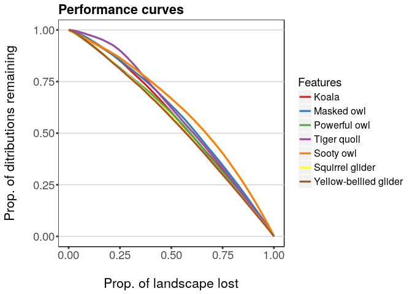

```r
plot(feature.curves.caz)
```

Plotting-methods for `ZCurvesDataFrame` and `ZGroupCurvesDataFrame` classes include a couple of convenience arguments as well. By default, the scale on x-axis ranges from 0 to 1 and has a label “Prop. of landscape lost”. The other way of presenting the x-axis is to have it range from 1 to 0 and label it “Proportion of landscape under conservation”. This behavior can be controlled by using the argument `invert.x` for `plot-method`. The title of the plot can be set using `main`-argument.

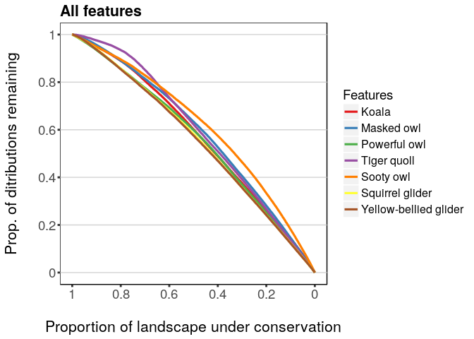

```r
plot(feature.curves.caz, invert.x = TRUE, main = "All features")
```

Argument `subs` can have a character vector of feature names to be plotted, i.e. a subset of all features. Different overall statistics can also be plotted. Statistics supported are: `mean`, `min`, and `w.mean` for feature-specific curves. Each of these is a logical argument that can be set to `TRUE`/`FALSE`. They correspond to “Average proportion remaining over all features”, “Minimum proportion remaining over all features”, and “Weighted average proportion remaining over all features” respectively.

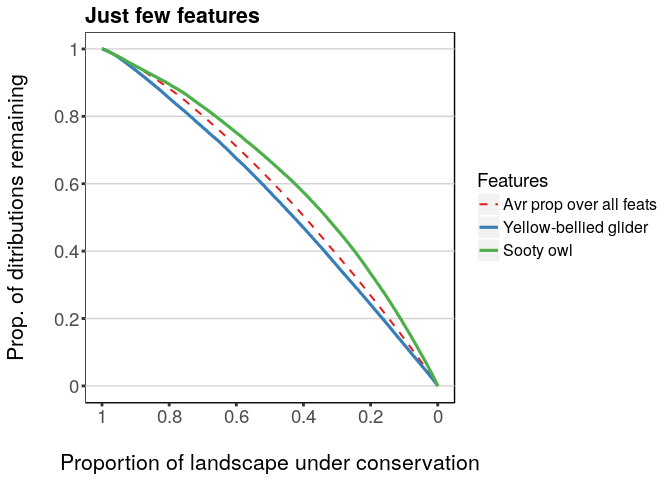

```r
plot(feature.curves.caz, invert.x = TRUE, main = "Just few features",
     subs = c('Yellow-bellied.glider', 'Sooty.owl'), mean = TRUE)
```

Group-specific curves can be plotted in similar fashion. Note that plotting group curves also respect the group names you may have set.

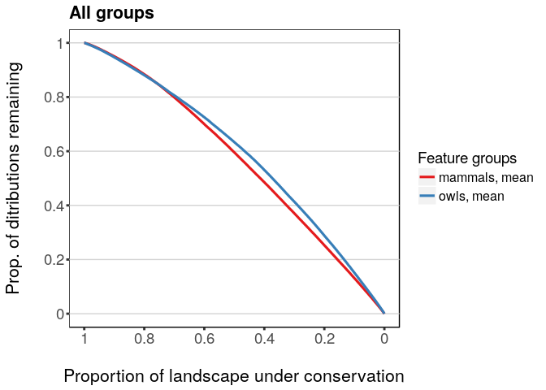

```r
plot(feature.grp.curves.caz, invert.x = TRUE, main = "All groups")
```

Subsetting works the same as with individual features.

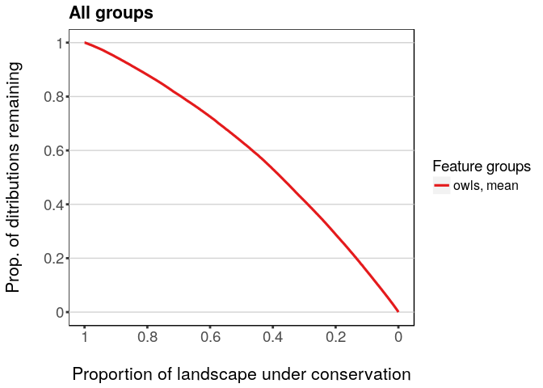

```r
plot(feature.grp.curves.caz, invert.x = TRUE, main = "All groups",
     subs = c('owls'))
```

Both feature- and group-specific curve plotting methods also have an argument called `monochrome`. Setting this argument to `TRUE` will use only monochrome colours which may be useful e.g. for publication figures.

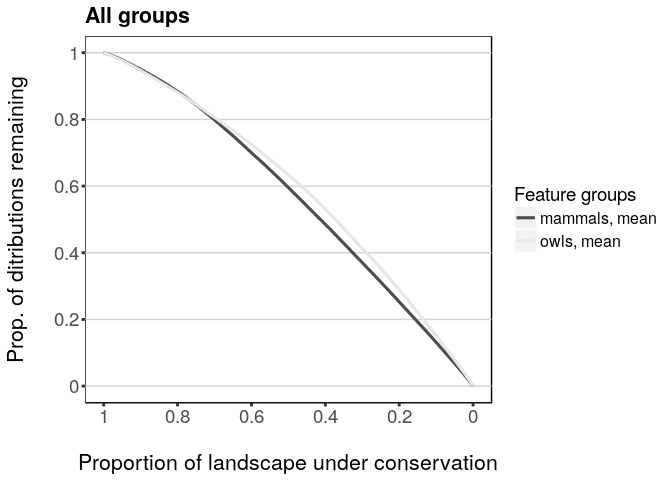

```r
plot(feature.grp.curves.caz, invert.x = TRUE, main = "All groups",
     monochrome = TRUE)
```

Group plotting also has a set of statistics which can be plotted, but the behavior is slightly different to that of features. What is plotted by default are group-specific mean values. Other statistics are `min`, `max`, and `w.mean` which correspond to “Minimum proportion remaining for a feature within group”, “Maxmimum proportion remaining for a feature within group”, and “Weighted average proportion remaining for group”. Note that `mean` will always be `TRUE` unless it’s explicitly set to `FALSE`.

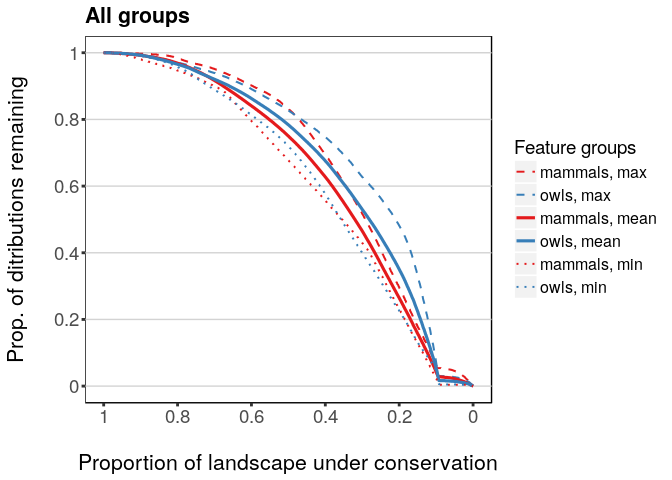

```r
plot(feature.grp.curves.mask, invert.x = TRUE, main = "All groups",
     mean = TRUE, min = TRUE, max = TRUE)
```

### 2.3 Plotting performance levels

If you want to summarize how much each feature has retained it’s occurrence level in a given stage of the cell removal process, you can easily created bar plots out of selected performance levels. For example, if you’d like to know how much of the original occurrence level each of species in our tutorial data has left when 10% percent of the landscape is under conservation, you could do the following:

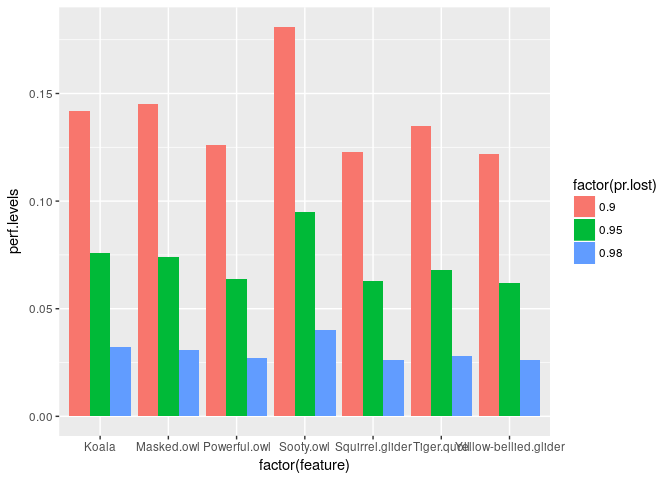

```r
library(ggplot2)
# NOTE: we're using melted=TRUE here
occr.remaining <- performance(results.caz, c(0.9, 0.95, 0.98), melted = TRUE)
ggplot(occr.remaining, aes(x = factor(feature), y = perf.levels,
                           fill = factor(pr.lost))) +
  geom_bar(position = "dodge", stat = "identity")
```

## 3. Raster results

### 3.1. Priority rank rasters

One of the main outputs of a Zonation analysis is the priority rank rasters which gives each cell in the landscape a value [0, 1] indicating the final priority rank (0 = the lowest, 1 = the highest). Rank raster is part of `Zresults` object just as the performance curves above. Method `rank_raster()` can be used to get the rank raster object. The color scheme used is really up to the user, but having a consistent and expressive color scheme for all the results helps. `zlegends()` can be used for ready-to-go color schemes that can used when plotting the raster objects.

```r
library(raster)
```

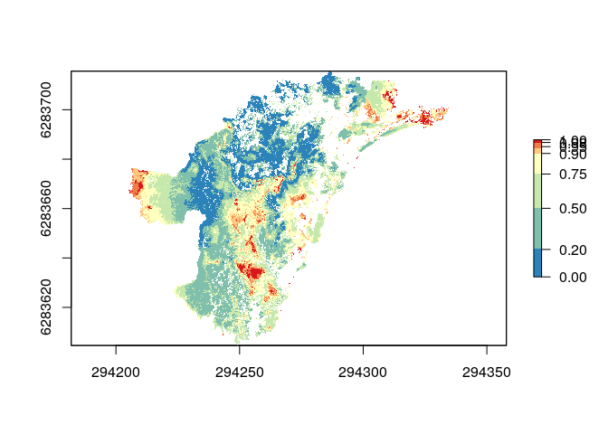

```r
rank.caz <- rank_raster(results.caz)
# Let's use a spectral color scheme designed for Zonation rank maps
leg <- zlegend("spectral")
plot(rank.caz, breaks = leg$values, col = leg$colors)
```

You can of course get all rank rasters individually from your project’s variants, but an alternative approach is to call `rank_rasters()` (note the plural in method name!) directly on your project object. This will result in a `RasterStack` object containing all the rank rasters as respective layers. If you want to plot all rank rasters in your project for comparison, you could do the following:

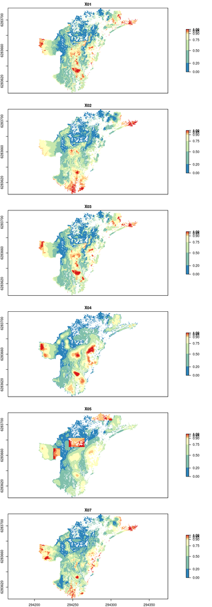

```r
# RasterStack is returned
all.ranks <- rank_rasters(tutorial.project)
plot(all.ranks, breaks = leg$values, col = leg$colors, nc = 1)
```

Naturally, all methods defined for a `RasterStack` object are available. For example, checking the distributions of individual stack layers (i.e. rank rasters) and the correlation between the values of layers can be done using `pairs()`. Following example examines correlation between variants 1-3.

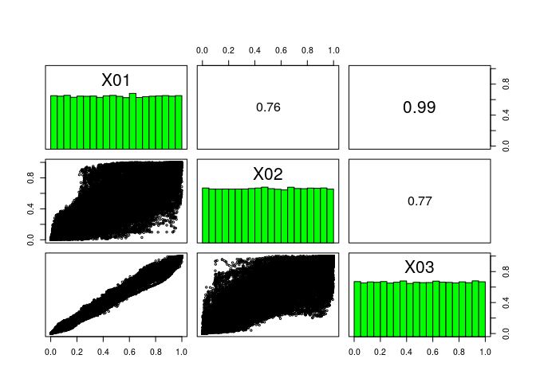

```r
pairs(stack(all.ranks[[1:3]]), method = "kendall")
```

Values are sampled from the whole distribution of values to increase execution speed. Note also that we are using `kendall` as method for correlation.

Masking is another useful analysis tool. In the following example we are using the mask file `mask_rs.tif` shipping with Zonation basic tutorial in order to inspect the distribution of priorities within a subset of the landscape (i.e. protected areas, PAs). In the following example, note that method `rank_raster()` has been implemented for class `Zvariant`. In other words, you can call it on both your variant or results object. `plot_hist()` accepts two rasters as arguments: first is the rank raster and the second one is a mask raster. Histogram is then plotted based on the values of the rank raster within the mask raster.

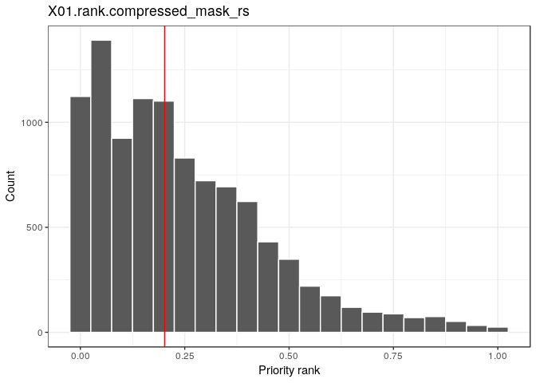

```r
pas.file <- system.file("extdata/data", "mask_rs.tif",
                        package = "zdat")
pas <- raster(pas.file)
# Re-class zeros as NA
pas[pas == 0] <- NA
# Plot the histogram of rank.caz within mask raster
plot_hist(x = rank.caz, pas, add.median = TRUE)
```

[rasterVis](http://oscarperpinan.github.io/rastervis/) is another useful package for plotting raster data. For example, `levelplot()` can be used to plot data and show a marginal plot of of a function across each coordinate (here using mean):

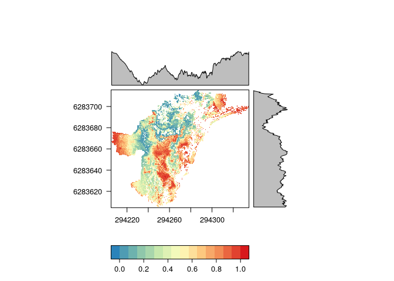

```r
library(rasterVis)
# Note that breaks in the following are different from the previous maps
levelplot(rank.caz, FUN.margin = mean,
          par.settings = rasterTheme(region = leg$colors))
```